# Geog533 Lab 10

Li Xi

## Question 1

Use R package UScensus2010county to complete the following tasks: (20 pt.)

### Question 1(a)

Plot a map of New York counties using the plot function.

```r
library(UScensus2010county)
data("new_york.county10")
shp <- new_york.county10
plot(shp)
```

[output not shown]

### Question 1(b)

Plot a map of New York counties using the qtm function.

```r
library(tmap)
qtm(shp,fill = "NAME10",fill.title = "NY counties")
```

[output not shown]

### Question 1(c)

How many counties in New York State?

```r
length(shp)
```

```
[1] 62
```

### Question 1(d)

Whatâs the 3-digit fips code of Broome County?

```r
Broome <- shp.df[shp.df$NAME10=="Broome",]
print(Broome$fips)
```

```
[1] "36007"
```

### Question 1(e)

```r
sum(shp$P0010001)
```

```
[1] 19378102
```

### Question 1(f)

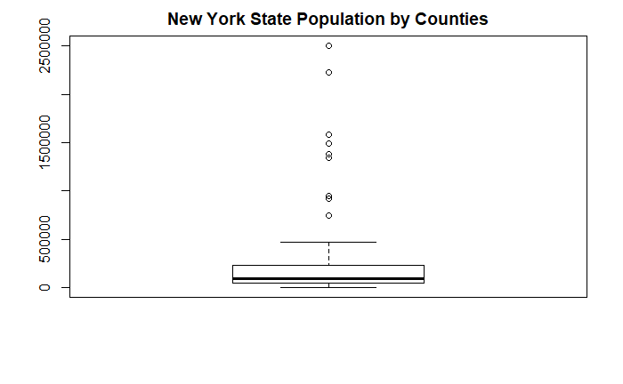

## Question 2

Use R package UScensus2010tract to complete the following tasks: (20 pt.)

```r
#install.packages("UScensus2010tract", repos="http://R-Forge.R-project.org")
```

### Question 2(a)

Plot a map of New York census tracts using the plot function.

```r
library(UScensus2010tract)
data("new_york.tract10")
tract <- new_york.tract10
plot(tract)
```

[output not shown]

### Question 2(b)

Compute the total population based on census tracts.

```r
df <- tract@data
sum(df$P0010001)
```

```
[1] 19378102
```

### Question 2(c)

Select all census tracts in Broome County and plot the map.

```r
library(UScensus2010)
```

[output not shown]

[output not shown]

### Question 2(d)

Whatâs the total population of Broome County?

```r
broome.sum <- sum(broome$P0010001)
```

[output not shown]

### Question 2(e)

Create a histogram and a boxplot of population based on census tracts of Broome County.

```r
hist(broome$P0010001,main="Broome County Population by Census Tract")
boxplot(broome$P0010001,main="Broome County Population by Census Tract")
```

[output not shown]

### Question 2(f)

Select the first five columns of the shapefile of Broome County census tract; add a new population ratio column (= census tract population / county population); save the new shapefile to the hard drive.

```r
broome.f <- broome[,1:5]
View(broome.f)
broome.f$popRatio <- broome.f$P0010001/broome.sum
library(rgdal)
writeOGR(broome.f,dsn="output",layer="broome.f",driver="ESRI Shapefile",overwrite_layer = TRUE)
readOGR(dsn = "output", layer = "broome.f")
```

## Question 3

Use R packages raster and ncdf4 to complete the following tasks: (20 pt.)

```r
library(raster)
library(ncdf4)
```

### Question 3(a)

Load the multi-band raster dataset âNDVI.ncâ into R.

```r
ras <- brick("NDVI.nc")
ras
```

### Question 3(b)

Get the basic information about the dataset, including the number of rows, columns, cells, and bands; spatial resolution, extent, bounding box, and projection.

```r
nrow(ras)
ncol(ras)
ncell(ras)
nlayers(ras)
res(ras)
extent(ras)
bbox(ras)
projection(ras)
```

### Question 3(c)

Aggregate all bands to generate a mean NDVI raster and a maximum NDVI raster; save the two new raster datasets to the hard drive.

```r
mean(ras)
writeRaster(mean(ras),filename = "mean_ras.tif",overwrite=TRUE)
max(ras)
writeRaster(max(ras),filename = "max_ras.tif",overwrite=TRUE)
```

### Question 3(d)

```r
plot(ras[[1:12]])
```

[output not shown]

### Question 3(e)

Create histograms of monthly NDVI of the year 2001.

```r
hist(ras[[13:24]])
```

[output not shown]

### Question 3(f)

Plot the NDVI map of July 2000; click any location with data on the map and retrieve the NDVI time series for all years; plot the NDVI time series of the selected location.

```r
plot(ras,7)
#values <- click(ndvi.rb, n=1, xy=FALSE)
values <- ras[60,60]
plot((as.vector(values)), type="b")
```

[output not shown]